# rifiComparative

Loubna Youssar

2022-07-06

## 0. Installation

Required dependencies are cited on README, please make sure they are properly installed (README). All functions should be located on the same folder and add them to your path directory.

## II. Workflow

### 1. Joining data

The first step is combining the data from two conditions. The data are combined by row on one hand and combined by column on the other hand. Both objects are saved and used as input for the next analysis.

The functions used are:

`loading_fun`: you need to load the rifi statistics outputs from each condition and put all in one directory. The “cdt” is added referring to the sample condition.

Very important: you will need to run the differential expression at probe/bin level. This is the log2FC(intensity) or log2FC(mRNA at time 0). Pick-up the logFC, the p_value adjusted, probe position and strand columns. Save the first two as ‘logFC_int’ and ‘P.Value’. You can use either `left_join` or `right_join` from dplyr package to join both data by strand and position.

```r
data(stats_se_cdt1)
data(stats_se_cdt2)
data(differential_expression)
inp_s <-
    loading_fun(stats_se_cdt1, stats_se_cdt2, differential_expression)[[1]]
head(inp_s, 5)
```

```
##   strand position ID FLT intensity probe_TI flag position_segment     delay
## 1      +       67  1   0  1367.080       -1    _              S_1 1.4190839
## 2      +      153  2   0  3316.336       -1    _              S_1 1.9343216
## 3      +      199  3   0  1112.101       -1    _              S_1 0.6442441
## 4      +      259  4   0  2012.294        1    _              S_1 0.0010000
## 5      +      320  5   0  1627.467       -1    _              S_1 1.9506707
##    half_life TI_termination_factor delay_fragment velocity_fragment intercept
## 1 0.63658399                    NA            D_1          5381.643  1.707418
## 2 0.07033786                    NA            D_1          5381.643  1.707418
## 3 1.23339859                    NA          D_1_O          5381.643  1.707418
## 4 0.05594761                    NA          D_1_O          5381.643  1.707418
## 5 0.07012892                    NA            D_1          5381.643  1.707418
##          slope HL_fragment HL_mean_fragment intensity_fragment
## 1 0.0001858169        Dc_1        0.4851184                I_1
## 2 0.0001858169        Dc_1        0.4851184                I_1
```

[output cut: 45 more lines]

```r
inp_f <-
    loading_fun(stats_se_cdt1, stats_se_cdt2, differential_expression)[[2]]
head(inp_f, 5)
```

```
##   strand position ID FLT intensity probe_TI  flag position_segment       delay
## 1      +       67  1   0  1885.621       -1     _              S_1   1.8146852
## 2      +      153  2   0  4311.070        1     _              S_1   7.0634447
## 3      +      199  3   0  1285.397       -1     _              S_1   0.7950453
## 4      +      259  4   0  3393.836        1 _ABG_              S_1 126.7149209
## 5      +      320  5   0  2245.636       -1     _              S_1   1.4386446
##     half_life TI_termination_factor delay_fragment velocity_fragment intercept
## 1  0.08018944                    NA            D_1               Inf  1.794761
## 2  0.29227109                    NA            D_1               Inf  1.794761
## 3  0.77429388                    NA            D_1               Inf  1.794761
## 4 23.34891958                    NA          D_1_O               Inf  1.794761
## 5  0.41681710                    NA            D_1               Inf  1.794761
##   slope HL_fragment HL_mean_fragment intensity_fragment intensity_mean_fragment
## 1     0        Dc_1        0.3598576                I_1                2371.559
## 2     0        Dc_1        0.3598576                I_1                2371.559
```

[output cut: 45 more lines]

```r
data(inp_s)
data(inp_f)
data_combined_minimal <-
joining_data_row(input1 = inp_s, input2 = inp_f)
head(data_combined_minimal, 5)
```

```
##   strand position ID FLT intensity probe_TI flag position_segment     delay
## 1      +       67  1   0  1367.080       -1    _              S_1 1.4190839
## 2      +      153  2   0  3316.336       -1    _              S_1 1.9343216
## 3      +      199  3   0  1112.101       -1    _              S_1 0.6442441
## 4      +      259  4   0  2012.294        1    _              S_1 0.0010000
## 5      +      320  5   0  1627.467       -1    _              S_1 1.9506707
##    half_life TI_termination_factor delay_fragment velocity_fragment intercept
## 1 0.63658399                    NA            D_1          5381.643  1.707418
## 2 0.07033786                    NA            D_1          5381.643  1.707418
## 3 1.23339859                    NA          D_1_O          5381.643  1.707418
## 4 0.05594761                    NA          D_1_O          5381.643  1.707418
## 5 0.07012892                    NA            D_1          5381.643  1.707418
##          slope HL_fragment HL_mean_fragment intensity_fragment
## 1 0.0001858169        Dc_1        0.4851184                I_1
## 2 0.0001858169        Dc_1        0.4851184                I_1
```

[output cut: 45 more lines]

```r
data(data_combined_minimal)
df_comb_minimal <- joining_data_column(data = data_combined_minimal)
head(df_comb_minimal, 5)
```

```
##   strand position ID intensity.cdt1 position_segment half_life.cdt1
## 1      +       67  1       1367.080              S_1     0.63658399
## 2      +      153  2       3316.336              S_1     0.07033786
## 3      +      199  3       1112.101              S_1     1.23339859
## 4      +      259  4       2012.294              S_1     0.05594761
## 5      +      320  5       1627.467              S_1     0.07012892
##   TI_termination_factor.cdt1 HL_fragment.cdt1 intensity_fragment.cdt1
## 1                         NA             Dc_1                     I_1
## 2                         NA             Dc_1                     I_1
## 3                         NA             Dc_1                     I_1
## 4                         NA             Dc_1                     I_1
## 5                         NA             Dc_1                     I_1
##   TI_termination_fragment.cdt1   logFC_int     P.Value intensity.cdt2
## 1                         <NA> -0.20137817 0.033395012       1885.621
## 2                         <NA>  0.07306854 0.674892028       4311.070
## 3                         <NA> -0.04264460 0.512469947       1285.397
## 4                         <NA> -0.37075316 0.002843646       3393.836
## 5                         <NA> -0.14561154 0.280129057       2245.636
##   half_life.cdt2 TI_termination_factor.cdt2 HL_fragment.cdt2
## 1     0.08018944                         NA             Dc_1
## 2     0.29227109                         NA             Dc_1
## 3     0.77429388                         NA             Dc_1
## 4    23.34891958                         NA           Dc_1_O
## 5     0.41681710                         NA             Dc_1
##   intensity_fragment.cdt2 TI_termination_fragment.cdt2
## 1                     I_1                         <NA>
## 2                     I_1                         <NA>
## 3                     I_1                         <NA>
## 4                     I_1                         <NA>
## 5                     I_1                         <NA>
```

### 2. Penalties

Same as rifi workflow, to get the best segmentation we need the optimal penalties. To calculate HL penalty, the difference between half-life from both conditions is calculated and added as distance_HL variable to df_comb_minimal data frame. On other hand the logFC_int is used to assign penalties for intensity values and added as distance_int variable. df_comb_minimal with the additional variables is named penalties_df.

The functions needed for penalty are:

`make_pen` calls one of two available penalty functions to automatically assign penalties for the dynamic programming. Four functions are called:

- `make_pen`
- `fragment_HL_pen`
- `fragment_inty_pen`
- `score_fun_ave`

#### 1. `make_pen`

`make_pen` calls one of two available penalty functions to automatically assign penalties for the dynamic programming. the function iterates over many penalty pairs and picks the most suitable pair based on the difference between wrong and correct splits. The sample size, penalty range and resolution as well as the number of cycles can be customized. The primary start parameters create a matrix with n = rez_pen rows and n = rez_pen_out columns with values between sta_pen/sta_pen_out and end_pen/end_pen_out. The best penalty pair is picked. If dept is bigger than 1 the same process is repeated with a new matrix of the same size based on the result of the previous cycle. Only position segments with length within the sample size range are considered for the penalties to increase run time. Also, outlier penalties cannot be smaller than 40% of the respective penalty. For more detail check vignette from rifi package.

#### 2. `fragment_HL_pen`

`fragment_HL_pen` is called by `make_pen` function to automatically assign penalties for the dynamic programming of half-life fragments. The function used for `fragment_HL_pen` is `score_fun_ave`. `score_fun_ave` scores the values of y on how close they are to the mean. for more details, see below.

```r
df_comb_minimal[,"distance_HL"] <-
    df_comb_minimal[, "half_life.cdt1"] - df_comb_minimal[, "half_life.cdt2"]

pen_HL <- make_pen(
    probe = df_comb_minimal,
    FUN = rifiComparative:::fragment_HL_pen,
    cores = 2,
    logs = as.numeric(rep(NA, 8)),
    dpt = 1,
    smpl_min = 10,
    smpl_max = 50,
    sta_pen = 0.5,
    end_pen = 4.5,
    rez_pen = 9,
    sta_pen_out = 0.5,
    end_pen_out = 3.5,
    rez_pen_out = 7
)
```

#### 3. `fragment_inty_pen`

`fragment_inty_pen` is called by `make_pen` function to automatically assign penalties for the dynamic programming of intensity fragments. The function used is `score_fun_ave`.

```r
df_comb_minimal[,"distance_int"] <- df_comb_minimal[,"logFC_int"]

pen_int <- make_pen(
    probe = df_comb_minimal,
    FUN = rifiComparative:::fragment_inty_pen,
    cores = 60,
    logs = as.numeric(rep(NA, 8)),
    dpt = 1,
    smpl_min = 10,
    smpl_max = 50,
    sta_pen = 0.5,
    end_pen = 4.5,
    rez_pen = 9,
    sta_pen_out = 0.5,
    end_pen_out = 3.5,
    rez_pen_out = 7
)
```

```r
data(df_comb_minimal)
penalties_df <- penalties(df_comb_minimal)[[1]]
pen_HL <- penalties(df_comb_minimal)[[2]]
pen_int <- penalties(df_comb_minimal)[[3]]
head(penalties_df, 5)
```

```
##   strand position ID intensity.cdt1 position_segment half_life.cdt1
## 1      +       67  1       1367.080              S_1     0.63658399
## 2      +      153  2       3316.336              S_1     0.07033786
## 3      +      199  3       1112.101              S_1     1.23339859
## 4      +      259  4       2012.294              S_1     0.05594761
## 5      +      320  5       1627.467              S_1     0.07012892
##   TI_termination_factor.cdt1 HL_fragment.cdt1 intensity_fragment.cdt1
## 1                         NA             Dc_1                     I_1
## 2                         NA             Dc_1                     I_1
## 3                         NA             Dc_1                     I_1
## 4                         NA             Dc_1                     I_1
## 5                         NA             Dc_1                     I_1
##   TI_termination_fragment.cdt1   logFC_int     P.Value intensity.cdt2
## 1                         <NA> -0.20137817 0.033395012       1885.621
## 2                         <NA>  0.07306854 0.674892028       4311.070
## 3                         <NA> -0.04264460 0.512469947       1285.397
## 4                         <NA> -0.37075316 0.002843646       3393.836
## 5                         <NA> -0.14561154 0.280129057       2245.636
##   half_life.cdt2 TI_termination_factor.cdt2 HL_fragment.cdt2
## 1     0.08018944                         NA             Dc_1
## 2     0.29227109                         NA             Dc_1
## 3     0.77429388                         NA             Dc_1
## 4    23.34891958                         NA           Dc_1_O
## 5     0.41681710                         NA             Dc_1
##   intensity_fragment.cdt2 TI_termination_fragment.cdt2 distance_HL distance_int
## 1                     I_1                         <NA>   0.5563945  -0.20137817
## 2                     I_1                         <NA>  -0.2219332   0.07306854
## 3                     I_1                         <NA>   0.4591047  -0.04264460
## 4                     I_1                         <NA> -23.2929720  -0.37075316
## 5                     I_1                         <NA>  -0.3466882  -0.14561154
```

#### 4. `score_fun_ave`

`score_fun_ave` scores the values of y on how close they are to the mean. for more details, see below.

### 3. Fragmentation

After finding the optimal set of penalties, fragmentation process could be applied. The functions used are:

`fragment_HL` `fragment_inty` `score_fun_ave`

#### 1. `fragment_HL`

`fragment_HL` performs the half_life fragmentation and assigns all gathered information to the probe based data frame. The columns “HL_comb_fragment” and “HL_mean_comb_fragment” are added to dataframe. `fragment_HL` makes half-life_fragments and assigns the mean of each fragment.

```r
penalties_df <-
    fragment_HL(
    probe = penalties_df,
    cores = 2,
    pen = pen_HL[[1]][[9]],
    pen_out = pen_HL[[1]][[10]]
)
```

#### 2. `fragment_inty`

`fragment_inty` performs the intensity fragmentation and assigns all gathered information to the probe based data frame. The columns “intensity_comb_fragment” and “intensity_mean_comb_ fragment” are added to the dataframe. `fragment_inty` makes intensity_fragments and assigns the mean of each fragment. The hierarchy is not followed, fragments from different size could be generated independently of half-life fragments.

```r
fragment_int <-
    fragment_inty(
        probe = penalties_df,
        cores = 2,
        pen = pen_int[[1]][[9]],
        pen_out = pen_int[[1]][[10]]
    )
head(fragment_int, 5)
```

```
##   strand position ID intensity.cdt1 position_segment half_life.cdt1
## 1      +       67  1       1367.080              S_1     0.63658399
## 2      +      153  2       3316.336              S_1     0.07033786
## 3      +      199  3       1112.101              S_1     1.23339859
## 4      +      259  4       2012.294              S_1     0.05594761
## 5      +      320  5       1627.467              S_1     0.07012892
##   TI_termination_factor.cdt1 HL_fragment.cdt1 intensity_fragment.cdt1
## 1                         NA             Dc_1                     I_1
## 2                         NA             Dc_1                     I_1
## 3                         NA             Dc_1                     I_1
## 4                         NA             Dc_1                     I_1
## 5                         NA             Dc_1                     I_1
##   TI_termination_fragment.cdt1   logFC_int     P.Value intensity.cdt2
## 1                         <NA> -0.20137817 0.033395012       1885.621
## 2                         <NA>  0.07306854 0.674892028       4311.070
```

[output cut: 27 more lines]

#### 3. `score_fun_ave`

`score_fun_ave` is the score function used by dynamic programming for intensity fragmentation, for more details, see below.

### 4. Statistics

To check segment significance, t-test with two.sided was used. Each fragment was tested for the number of probes involved in each condition.

```r
data(fragment_int)
stats_df_comb_minimal <- statistics(data= fragment_int)[[1]]
df_comb_uniq_minimal <- statistics(data= fragment_int)[[2]]
```

### 5. Visualization

The visualization depicts half-life and intensity slots of the fragments result of the dynamic programming. Since hierarchy is not applied, the fragments from half-life and intensity are independent.

```r
data(data_combined_minimal)
data(stats_df_comb_minimal)
data(annot_g)
rifi_visualization_comparison(
     data = data_combined_minimal,
     data_c = stats_df_comb_minimal,
     genomeLength = annot_g[[2]],
     annot = annot_g[[1]]
     )
```

```
## [1] 1
## [1] "1: no data on negative strand"
```

```
## [1] 2
## [1] "2: no data on negative strand"
```

```
## [1] 3
## [1] "3: no data on negative strand"
```

```
## [1] 4
## [1] "4: no data on negative strand"
```

```
## [1] 5
## [1] "5: no data on negative strand"
```

[output not shown]

[output cut: 338 more lines]

Three objects are required:

The plot is located on vignette “genome_fragments_comparison.pdf” and shows 3 sections: annotation, half-life difference and log2FC (mRNA=time0 or intensity). Either half_life difference or log2FC(intensity), the line 0 indicate no changes between both conditions. Conditions 1 and 2 are indicated by blue and lilac color respectively. Fragments result of dynamic programming are indicated by different colors. The annotation englobes genome annotation preprocessed by gff3_preprocessing function included on the package and a superposed TU annotation of both conditions from rifi output.

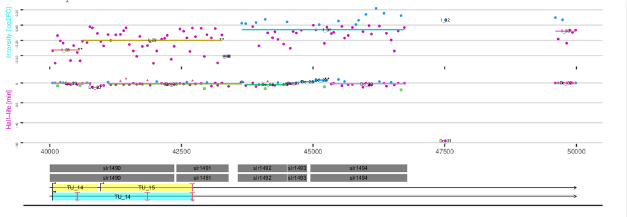

Figure 1: **genome fragments visualization of both conditions**

## III. Outputs

### 1. `adjusting_HLToInt`

`adjusting_HLToInt` function combines HL and intensity fragments generated without hierarchy on one hand and the genome annotation on other hand. The first step is adjusting the fragments from HL to intensity and vise-versa and join them to the genome annotation. To make HL and intensity segments comparable, log2FC(HL) is used instead of distance_HL. The fragments should have a significant p_value from t-test at least from one segmentation, either HL or intensity.

To generate the data frame, two objects are required:

The functions used are:

`p_value_function` extracts and return the p_values of HL and intensity segments respectively.

`eliminate_outlier_hl` eliminates outliers from HL fragments.

`eliminate_outlier_int` eliminates outliers from intensity fragments.

`mean_length_int` extracts the mean of the log2FC(intensity) fragments adapted to HL_fragments and their lengths.

`mean_length_hl` extracts the mean of log2FC(HL) fragments adapted to the intensity fragments and their lengths.

`calculating_rate` calculates decay rate and log2FC(intensity). Both are used to calculate synthesis rate.

The output data frame contains the corresponding columns:

**position**: position of the first fragment **region**: region annotation covering the fragments **gene**: gene annotation covering the fragments **locus_tag**: locus_tag annotation covering the fragments **strand**: The bin/probe specific strand (+/-) **fragment_HL**: Half-life fragments **fragment_int**: intensity fragments **position_frg_int**: position of the first fragment and the last position of the last fragment. **mean_HL_fragment**: mean of the HL of the fragments involved. **mean_int_fragment**: mean of the intensity of the fragments involved. **log2FC(decay_rate)**: log2FC(decay(condition1)/decay(condition2)). **log2FC(synthesis_rate)**: sum of log2FC(decay_rate) and log2FC(intensity). **Log2FC(HL)-Log2FC(int)**: sum of log2FC(decay_rate) and log2FC(intensity). **intensity_FC**: log2FC(mean(intensity(condition1))/mean(intensity(condition2))). **Log2FC(HL)-Log2FC(int)**: sum of log2FC(decay_rate) and log2FC(intensity). **p_value**:indicated by “*” means at least one fragment either HL fragment or intensity fragment has a significant p_value.

```r
data(stats_df_comb_minimal)
data(annot_g)
df_adjusting_HLToInt <- adjusting_HLToInt(data = stats_df_comb_minimal,
                                          annotation = annot_g[[1]])
head(df, 5)
```

[output not shown]

## IV. Plots

A serie of plots could be generated using `figures_fun` function. The function includes several functions:

`plot_decay_synt` `plot_heatscatter` `plot_density` `plot_histogram` `plot_scatter` `plot_volcano`

### 1. `plot_decay_synt`

The generated data frame “df_mean_minimal” could be used to plot changes in RNA decay rates (log fold, x-axis) versus the changes in RNA synthesis rates (log fold, y-axis) in the condition 1 versus condition 2. The black lines horizontal, vertical and diagonal are the median of synthesis_rate, decay_rate and mRNA at time 0 respectively. Dashed gray lines indicate 0.5-fold changes from 0 (gray lines) referring to unchanged fold. Coloration could be adjusted upon the parameter selected. In this case decay rate above .5 and synthesis rate below -.5 are highlighted in yellow. Segments could be labeled using geom_text_repel function, they are commented on the function.

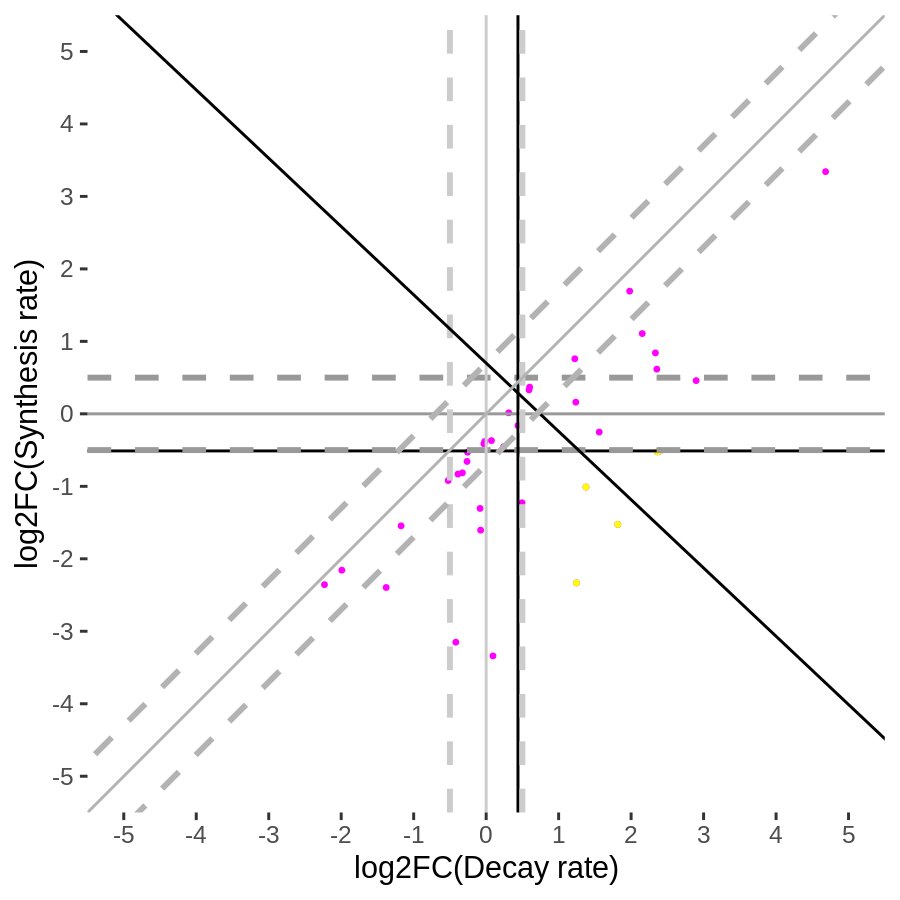

(#fig:Figure 2)**log2FC(Decay rate vs. Synthesis rate)**

### 2. `plot_heatscatter`

Heatscatter plot could be generated using “df_mean_minimal” data frame. It plots the changes in RNA decay rates (log fold, x-axis) versus the changes in RNA synthesis rates (log fold, y-axis) in the condition 1 versus condition 2. The coloring indicates the local point density.

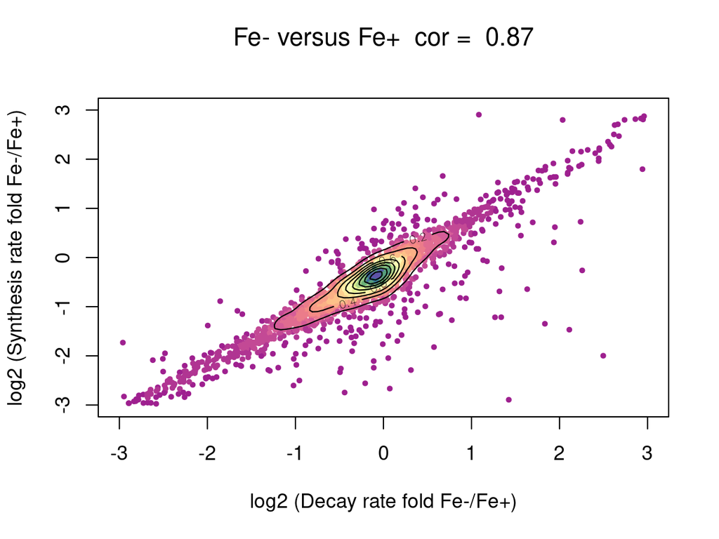

(#fig:Figure 3)**log2FC(heatscatter Decay rate vs. Synthesis rate)**

### 3. `plot_density`

The function uses the “data_combined_minimal” to plot the probe/bin half-life density in both conditions. Condition 1 and 2 could be indicated.

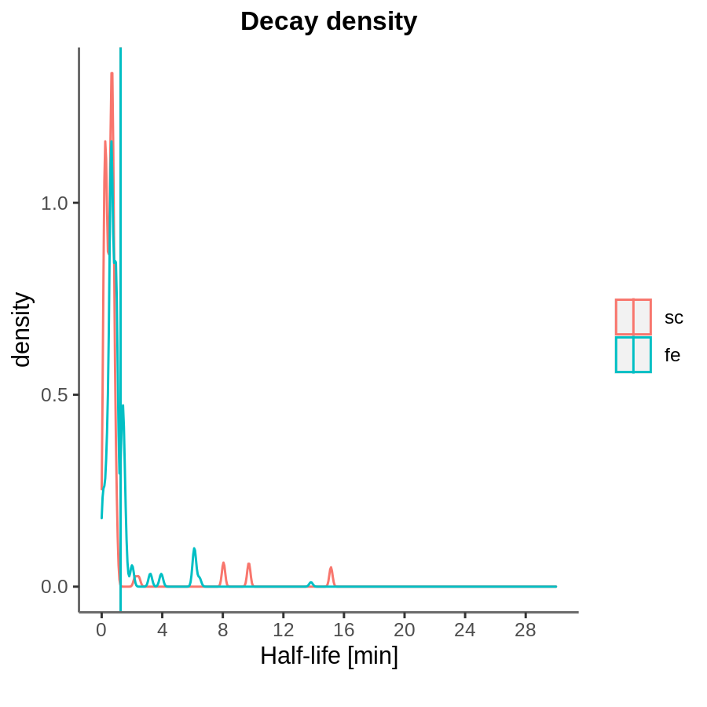

(#fig:Figure 4)**HL density**

### 4. `plot_histogram`

The function uses “df_comb_minimal” to plot a histogram of probe/bin half-life categories from 2 to 20 minutes in both conditions. Condition 1 and 2 could be indicated.

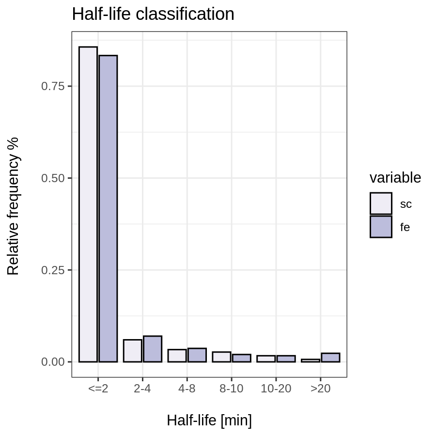

(#fig:Figure 5:)**HL histogram categories**

### 5. `plot_scatter`

A scatter plot of the bin/probe half-life.

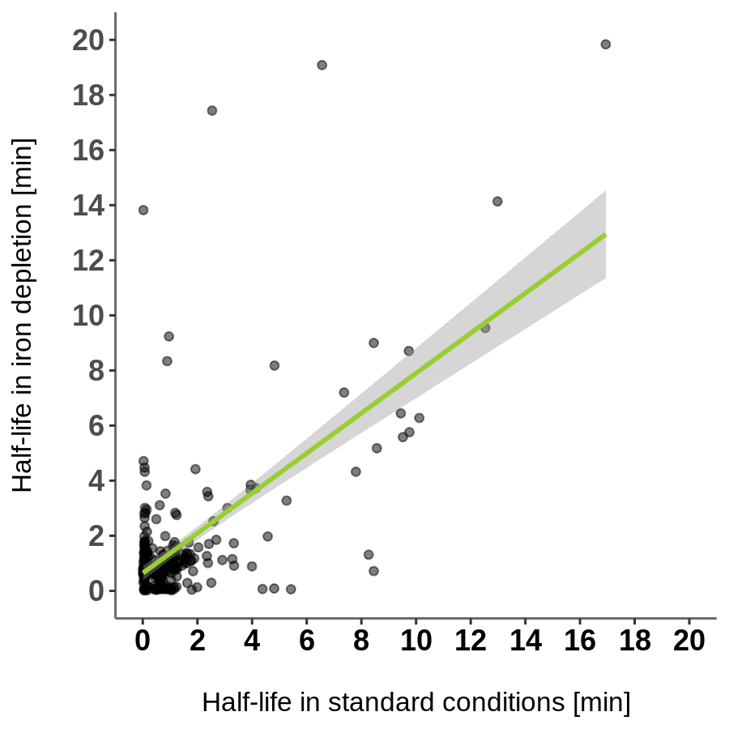

(#fig:Figure 6:)**HL Scatter Plot**

### 6. `plot_volcano`

A volcano plot of statistical significance (P value) versus magnitude of change (fold change).

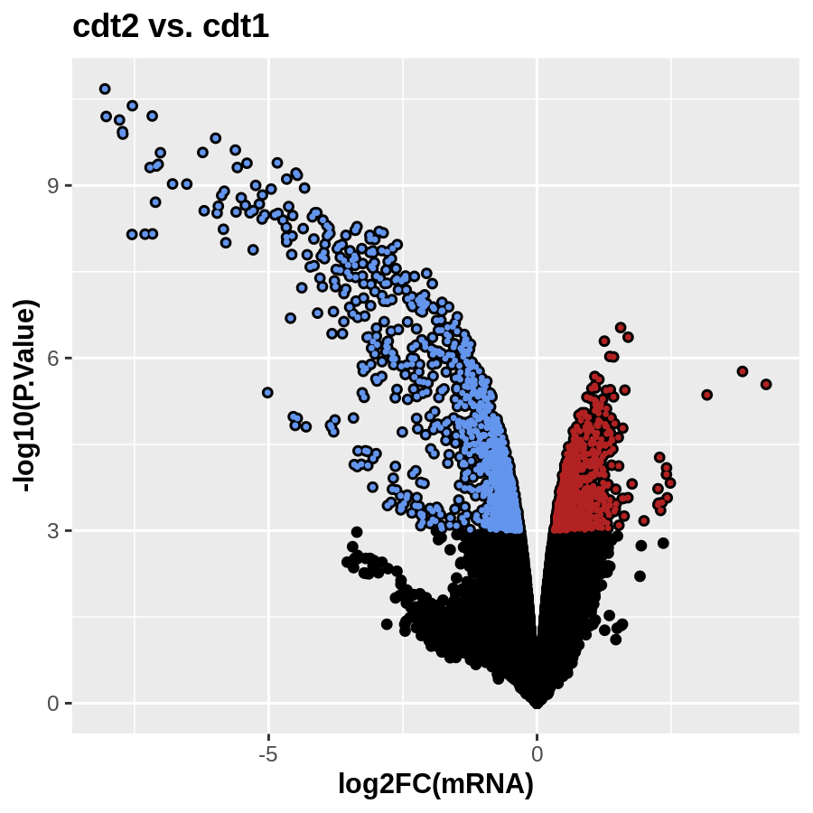

(#fig:Figure 7:)**Volcano Plot**

## III. Additional functions

### 1. `score_fun_ave`

`score_fun_ave` scores the difference of the values from their mean. `score_fun_ave` calculates the mean of a minimum 2 values **y** and substrates the difference from their mean. The IDs **z** and the sum of differences from the mean are stored. A new value y is added, the mean is calculated and the new IDs and sum of differences are stored. After several rounds, the minimum score and the corresponding IDs is selected and stored as the best fragment. `score_fun_ave` selects simultaneously for outliers, the maximum number is fixed previously. Outliers are those values with high difference from the mean, they are stored but excluded from the next calculation. The output of the function is a vector of IDs separated by “,”, a vector of mean separated by “_” and a vector of outliers separated by “,”.

### 2. `gff3_preprocess`

`gff3_preprocess` processes gff3 file from database, extracting gene names and locus_tag from all coding regions (CDS). Other features like UTRs, ncRNA, asRNA ect.. if available and the genome length are extracted. The output is a list of 2 elements.

The output data frame from `gff3_preprocess` function contains the following columns:

1. *region*: CDS or any other available like UTRs, ncRNA, asRNA
2. *start*: start position of the gene
3. *end*: end position of the gene
4. *strand*: +/-
5. *gene*: gene annotation if available otherwise locus_tag annotation replaces it
6. *locus_tag*: locus_tag annotation

```r
gff3_preprocess(path = gzfile(
   system.file("extdata", "gff_synechocystis_6803.gff.gz", package = "rifiComparative")
 ))
```

```
## [[1]]
## DataFrame with 5853 rows and 6 columns
##        region     start       end      strand        gene   locus_tag
##      <factor> <integer> <integer> <character> <character> <character>
## 1       CDS           1       772           +         sds   slr0611-2
## 2       asRNA       689       909           -  slr0612-as  slr0612-as
## 3       CDS         802      1494           +     slr0612     slr0612
## 4       5'UTR      1532      1576           +     slr0613     slr0613
## 5       CDS        1577      2098           +     slr0613     slr0613
## ...       ...       ...       ...         ...         ...         ...
## 5849    CDS     3571612   3572403           +     slr0610     slr0610
## 5850    ncRNA   3572945   3573067           -       SyR52     ncl1790
## 5851    ncRNA   3573080   3573200           -     ncl1800     ncl1800
## 5852    5'UTR   3573218   3573270           +     slr0611     slr0611
## 5853    CDS     3573271   3573470           +         sds     slr0611
##
## [[2]]
## [1] 3573470
```